**This notebook includes all data loading and formatting for raw EEG data supplied by Harvard Medical School; the notebook loads in, cleans and processes raw EEG data to create snapshots of the scalp in RGB as the EEG progresses.**

# [0]. Import Dependencies

```python
import os
import gc
import sys
import pickle
import random
import numpy as np
import pandas as pd
import seaborn as sns
import tensorflow as tf
import pyarrow.parquet as pq
import matplotlib.pyplot as plt
import matplotlib.animation as animation

from tqdm import tqdm
```

```python
from scipy import signal
from sklearn.manifold import MDS
from scipy.interpolate import griddata
```

# [1]. Load Raw EEG Data

Here, we simply load in all of the raw EEG data we have. Each sample contains 10,000 readings from 19 electrodes placed over the scalp. We load in each EEG sample, and then slice it into 7 overlapping pieces, each a snapshots that together can create the movie that is the EEG.

```python
# Load train metadata
metadata_train = pd.read_csv('/kaggle/input/hms-spectrogram-and-eeg-datasets/metadata_train.csv')
metadata_val = pd.read_csv('/kaggle/input/hms-spectrogram-and-eeg-datasets/metadata_val.csv')
metadata_train.head(3)
```

|  | eeg_id | eeg_sub_id | eeg_label_offset_seconds | spectrogram_id | spectrogram_sub_id | spectrogram_label_offset_seconds | label_id | patient_id | expert_consensus | seizure_vote | lpd_vote | gpd_vote | lrda_vote | grda_vote | other_vote |
| --- | --- | --- | --- | --- | --- | --- | --- | --- | --- | --- | --- | --- | --- | --- | --- |
| 0 | 2082870980 | 11 | 54.0 | 1365190123 | 20 | 1536.0 | 3814730053 | 56450 | LPD | 2 | 8 | 0 | 1 | 0 | 0 |
| 1 | 1015533435 | 0 | 0.0 | 615024327 | 21 | 2304.0 | 2124104338 | 19638 | Other | 0 | 0 | 0 | 0 | 0 | 3 |
| 2 | 269545663 | 0 | 0.0 | 1173213884 | 0 | 0.0 | 3454652513 | 6935 | Other | 0 | 0 | 0 | 0 | 0 | 2 |

```python
# Define constants
sampling_frequency = 200
seconds_per_reading = 50
```

```python
# Create a list of all raw EEG readings
raw_eeg_list = []

for index, row in tqdm(metadata_train.iterrows(), total = len(metadata_train)):

    # Extract relevant ID
    eeg_id = row['eeg_id']
    eeg_label_offset_seconds = row['eeg_label_offset_seconds']

    # Load corresponding parquet file
    parquet_filename = os.path.join("/kaggle/input/hms-harmful-brain-activity-classification/train_eegs", f"{eeg_id}.parquet")
    eeg_data = pq.read_table(parquet_filename).to_pandas()

    # Extract EEG data starting at the correct offset
    start_index = int(eeg_label_offset_seconds * sampling_frequency)
    end_index = start_index + seconds_per_reading * sampling_frequency

    # Select the required readings for each column
    selected_readings = eeg_data.iloc[start_index:end_index]
    selected_readings = selected_readings.ffill()
    selected_readings = selected_readings.bfill()

    # Separate reading into 7 overlapping snapshots
    snapshots = []
    for row_idx in range(7):

        start_idx = row_idx * 1000
        end_idx = start_idx + 4000
        snapshot = selected_readings.iloc[start_idx:end_idx, :]
        snapshots.append(snapshot)

    raw_eeg_list.append(snapshots)
```

# [2]. Prepare Electrode Data

EEG, widely employed in noninvasive neuroimaging, detects changes in scalp electrical voltage resulting from cortical activity. Comparatively, EEG data can be likened to a multi-channel "speech" signal, where each "microphone" (EEG electrode) captures signals from distinct "speakers" (representing activity in cortical regions). The EEG electrodes are distributed over the scalp in a 3-D space. To transform the spatially distributed activity maps as 2-D images, we need to first project the location of electrodes down onto a 2-D surface. Such a transformation should preserve the relative distance between neighboring electrodes, and so we employ Multi-Dimensional Scaling to do just that below. A relatively simple algorithm, the main goal of MDS is to map objects into a lower-dimensional space while preserving their pairwise distances or dissimilarities as much as possible.

```python
# Read in 3D locations of electrodes, extract their names
electrodes_xyz = pd.read_csv('/kaggle/input/hms-spectrogram-and-eeg-datasets/electrode_coords.csv')
electrode_names = electrodes_xyz['electrode'].values
electrodes_xyz.head(3)
```

|  | electrode | x | y | z |
| --- | --- | --- | --- | --- |
| 0 | Fp1 | -21.5 | 70.2 | -0.1 |
| 1 | Fp2 | 28.4 | 69.1 | -0.4 |
| 2 | Fz | 0.6 | 40.9 | 53.9 |

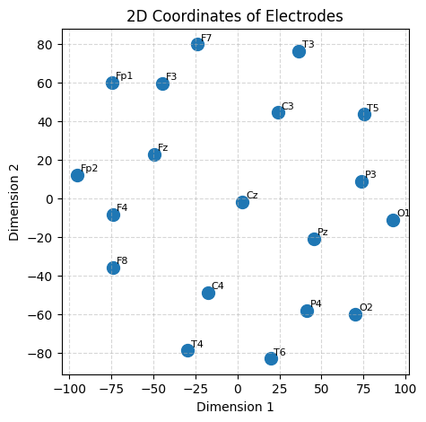

```python
# Project the locations onto a 2D surface

# Drop unnecessary columns
data = electrodes_xyz.drop(columns = ['electrode'])

# Initialize MDS with 2 dimensions
mds = MDS(n_components = 2, dissimilarity = 'euclidean',
          random_state = 28, normalized_stress = 'auto')

# Fit MDS and transform data
reduced_coordinates = mds.fit_transform(data)

# Create DataFrame with electrode name and reduced coordinates
reduced_df = pd.DataFrame({
    'electrode': electrodes_xyz['electrode'],
    'd1': reduced_coordinates[:, 0],
    'd2': reduced_coordinates[:, 1]
})

# Plot the 2D coordinates
plt.figure(figsize = (5, 5))
plt.scatter(reduced_df['d1'], reduced_df['d2'], s = 100)

# Add labels for each electrode
for i, txt in enumerate(reduced_df['electrode']):
    plt.annotate(txt, (reduced_df['d1'][i] + 2, reduced_df['d2'][i] + 2), fontsize = 8)

plt.xlabel('Dimension 1')
plt.ylabel('Dimension 2')
plt.title('2D Coordinates of Electrodes')
plt.grid(alpha = 0.5, linestyle = '--')
plt.show()
```

```python
reduced_df.to_csv('mapped_electrode_coords.csv', index = False)
```

# [3]. Create EEG Snapshot Images

Fast Fourier Transform (FFT) is performed on the time series for each trial/electrode snapshot to estimate the power spectrum of the signal. Oscillatory cortical activity related to memory operations primarily exists in three frequency bands of theta (4-8Hz), alpha (8-12Hz), and beta (12-30Hz), and FFT can basically decompose the raw EEG data into these component signal bands. We can then measure the power/energy at each frequency in the signal.

```python
# Define theta-alpha-beta wave separator function
def extract_frequency_band_features(raw_eeg, electrode_names):
    # Define EEG frequency bands
    eeg_bands = {'Theta': (4, 8), 'Alpha': (8, 12), 'Beta': (12, 30)}

    result_data = []

    for electrode in electrode_names:
        band_power = {}
        for band in eeg_bands:
            low, high = eeg_bands[band]

            # Filter signal for the specific band
            band_pass_filter = signal.butter(3, [low, high], btype = 'bandpass', fs = sampling_frequency, output = 'sos')
            filtered = signal.sosfilt(band_pass_filter, raw_eeg[electrode])

            # Calculate band power
            band_power[band] = np.sum(np.abs(filtered))

        # Append electrode data to the list
        result_data.append({'electrode': electrode, **band_power})

    # Convert the list of dictionaries into a DataFrame
    result_df = pd.DataFrame(result_data)

    return result_df
```

```python
# Create wave dataframes for each snapshot
intermediate_eeg_list = []
for raw_eeg in raw_eeg_list:

    intr_snapshots = []
    for snapshot in raw_eeg:
        band_df = extract_frequency_band_features(snapshot, electrode_names)
        intr_snapshots.append(band_df)

    intermediate_eeg_list.append(intr_snapshots)
    if len(intermediate_eeg_list) % 1000 == 0:
        print("Batch of 1000 items completed.")

del raw_eeg_list
```

```
Batch of 1000 items completed.
Batch of 1000 items completed.
Batch of 1000 items completed.
Batch of 1000 items completed.
Batch of 1000 items completed.
Batch of 1000 items completed.
Batch of 1000 items completed.
Batch of 1000 items completed.
Batch of 1000 items completed.
Batch of 1000 items completed.
Batch of 1000 items completed.
Batch of 1000 items completed.
Batch of 1000 items completed.
Batch of 1000 items completed.
```

We can use outlier-aware scaling in the form of using the median and median absolute deviations (MADs) to decided on which values are or are not outliers (potentially due to electrode misplacement or measurement error). After taking the logarithm of each list of theta/alpha/beta band values to create a normal-looking wave, we can use this outlier processign step to create a roughly normal curve that we can map onto three color channels Red, Green and Blue to create images of scalp signals.

```python
# Define MAD calculating function
def median_absolute_deviation(data, med):
    abs_deviations = [np.abs(x - med) for x in data]
    return np.median(abs_deviations)
```

```python
bands = ['Theta', 'Alpha', 'Beta']
band_values, band_scalers = [], []

for band in bands:

    # Collapse all values of a band into a list
    all_values = []
    for snapshots in intermediate_eeg_list:
        for snapshot in snapshots:
            all_values.extend(snapshot[[band]].values.flatten())

    # Convert values to floats & sort
    all_values = [float(value) for value in all_values]
    all_values = sorted(all_values)

    # Take the log of all values
    all_values = np.log(all_values)

    # Find the median and MAD
    med = np.median(all_values)
    mad = median_absolute_deviation(all_values, med)

    # Find outlier cutoffs
    max_cutoff = med + 6 * mad
    min_cutoff = med - 6 * mad

    # Replace outliers
    all_values = [x if x <= max_cutoff else max_cutoff for x in all_values]
    all_values = [x if x >= min_cutoff else min_cutoff for x in all_values]

    all_values = (all_values - min_cutoff) / (max_cutoff - min_cutoff) * 255

    scalers = {'Median': med, 'MAD': mad}
    band_scalers.append(scalers)

    band_values.append(all_values)
```

```python
# Save the outlier bounds for data transformation
filename = "/kaggle/working/band_scaling_bounds.pkl"

# Open the file in write-binary mode and save the data
with open(filename, 'wb') as file:
    pickle.dump(band_scalers, file)
```

```python
# Define outlier cutoff function
def apply_cutoff(x, min_cutoff, max_cutoff):
    if x > max_cutoff:
        x = max_cutoff
    elif x < min_cutoff:
        x = min_cutoff

    return x

# Iterate over all snapshots to normalize/correct their values
for i in range(len(intermediate_eeg_list)):
    for j in range(len(bands)):
        for k in range(7):

            # Take the log of the values
            intermediate_eeg_list[i][k][bands[j]] = np.log(intermediate_eeg_list[i][k][bands[j]])

            # Find the median and MAD
            med = band_scalers[j]['Median']
            mad = band_scalers[j]['MAD']

            # Find outlier cutoffs
            max_cutoff = med + 6 * mad
            min_cutoff = med - 6 * mad

            # Replace outliers
            intermediate_eeg_list[i][k][bands[j]] = intermediate_eeg_list[i][k][bands[j]].apply(lambda x: apply_cutoff(x, min_cutoff, max_cutoff))

            # Normalize
            intermediate_eeg_list[i][k][bands[j]] = (intermediate_eeg_list[i][k][bands[j]] - min_cutoff) / (max_cutoff - min_cutoff) * 255
```

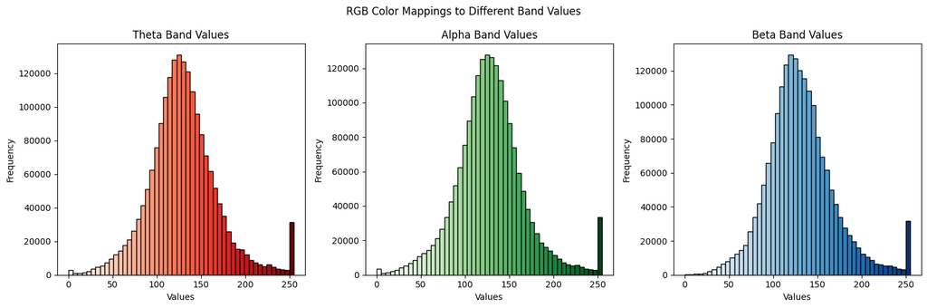

```python
# Visualize color extent of different electrode signals
fig, axs = plt.subplots(1, 3, figsize = (15, 5))

# Define color maps for each band
theta_colors = plt.cm.Reds(np.linspace(0, 1, 51))
alpha_colors = plt.cm.Greens(np.linspace(0, 1, 51))
beta_colors = plt.cm.Blues(np.linspace(0, 1, 51))

color_maps = {'Theta': theta_colors, 'Alpha': alpha_colors, 'Beta': beta_colors}

for i, (sublist, band) in enumerate(zip(band_values, bands)):
    n, bins, patches = axs[i].hist(sublist, bins = 50, edgecolor='black', color='white')
    bin_centers = 0.5 * (bins[:-1] + bins[1:])
    for c, p in zip(bin_centers, patches):
        color_index = int((c - min(bin_centers)) / (max(bin_centers) - min(bin_centers)) * 50)
        plt.setp(p, 'facecolor', color_maps[band][color_index])
    axs[i].set_title(f'{band} Band Values')
    axs[i].set_xlabel('Values')
    axs[i].set_ylabel('Frequency')

plt.suptitle("RGB Color Mappings to Different Band Values")
plt.tight_layout()
plt.show()
```

Finally, after extracting, cleaning, and scaling the signal bands, we can transform each snapshot into an image of the scalp, by combining the signal information with the 2-D electrode mapping. We use linear interpolation to fill in the values between electrodes, and as a result we get serial images representing signal strength across the scalp.

```python
final_eeg_images = []

# Define grid for interpolation
x = np.linspace(reduced_df['d1'].min(), reduced_df['d1'].max(), 32)
y = np.linspace(reduced_df['d2'].min(), reduced_df['d2'].max(), 32)
X, Y = np.meshgrid(x, y)

for snapshots in intermediate_eeg_list:

    final_images = []
    for snapshot in snapshots:

        # Interpolate color-values across scalp
        Z_theta = griddata((reduced_df['d1'].values, reduced_df['d2'].values), snapshot['Theta'], (X, Y), method = 'linear', fill_value = 0)
        Z_alpha = griddata((reduced_df['d1'].values, reduced_df['d2'].values), snapshot['Alpha'], (X, Y), method = 'linear', fill_value = 0)
        Z_beta = griddata((reduced_df['d1'].values, reduced_df['d2'].values), snapshot['Beta'], (X, Y), method = 'linear', fill_value = 0)

        Z_theta /= 255
        Z_alpha /= 255
        Z_beta /= 255

        # Create RGB image
        rgb_image = np.stack((Z_theta, Z_alpha, Z_beta), axis = -1)
        final_images.append(rgb_image)

    final_eeg_images.append(final_images)

del intermediate_eeg_list
```

```python
# Save train data
filename = "/kaggle/working/train_eeg_images.pkl"

# Open the file in write-binary mode and save the data
with open(filename, 'wb') as file:
    pickle.dump(final_eeg_images, file)
```

# [4]. Process Validation Raw EEG Data

```python
# Create a list of all raw EEG readings
raw_val_list = []

for index, row in tqdm(metadata_val.iterrows(), total = len(metadata_val)):

    # Extract relevant ID
    eeg_id = row['eeg_id']
    eeg_label_offset_seconds = row['eeg_label_offset_seconds']

    # Load corresponding parquet file
    parquet_filename = os.path.join("/kaggle/input/hms-harmful-brain-activity-classification/train_eegs", f"{eeg_id}.parquet")
    eeg_data = pq.read_table(parquet_filename).to_pandas()

    # Extract EEG data starting at the correct offset
    start_index = int(eeg_label_offset_seconds * sampling_frequency)
    end_index = start_index + seconds_per_reading * sampling_frequency

    # Select the required readings for each column
    selected_readings = eeg_data.iloc[start_index:end_index]
    selected_readings = selected_readings.ffill()
    selected_readings = selected_readings.bfill()

    # Separate reading into 7 overlapping snapshots
    snapshots = []
    for row_idx in range(7):

        start_idx = row_idx * 1000
        end_idx = start_idx + 4000
        snapshot = selected_readings.iloc[start_idx:end_idx, :]
        snapshots.append(snapshot)

    raw_val_list.append(snapshots)
```

```python
# Create wave dataframes for each snapshot
intermediate_val_list = []
for raw_eeg in raw_val_list:

    intr_snapshots = []
    for snapshot in raw_eeg:
        band_df = extract_frequency_band_features(snapshot, electrode_names)
        intr_snapshots.append(band_df)

    intermediate_val_list.append(intr_snapshots)
    if len(intermediate_val_list) % 500 == 0:
        print("Batch of 500 items completed.")

del raw_val_list
```

```
Batch of 500 items completed.
Batch of 500 items completed.
Batch of 500 items completed.
Batch of 500 items completed.
Batch of 500 items completed.
```

```python
# Iterate over all snapshots to normalize/correct their values
for i in range(len(intermediate_val_list)):
    for j in range(len(bands)):
        for k in range(7):

            # Take the log of the values
            intermediate_val_list[i][k][bands[j]] = np.log(intermediate_val_list[i][k][bands[j]])

            # Find the median and MAD
            med = band_scalers[j]['Median']
            mad = band_scalers[j]['MAD']

            # Find outlier cutoffs
            max_cutoff = med + 6 * mad
            min_cutoff = med - 6 * mad

            # Replace outliers
            intermediate_val_list[i][k][bands[j]] = intermediate_val_list[i][k][bands[j]].apply(lambda x: apply_cutoff(x, min_cutoff, max_cutoff))

            # Normalize
            intermediate_val_list[i][k][bands[j]] = (intermediate_val_list[i][k][bands[j]] - min_cutoff) / (max_cutoff - min_cutoff) * 255
```

```python
final_val_images = []

for snapshots in intermediate_val_list:

    final_images = []
    for snapshot in snapshots:

        # Interpolate color-values across scalp
        Z_theta = griddata((reduced_df['d1'].values, reduced_df['d2'].values), snapshot['Theta'], (X, Y), method = 'linear', fill_value = 0)
        Z_alpha = griddata((reduced_df['d1'].values, reduced_df['d2'].values), snapshot['Alpha'], (X, Y), method = 'linear', fill_value = 0)
        Z_beta = griddata((reduced_df['d1'].values, reduced_df['d2'].values), snapshot['Beta'], (X, Y), method = 'linear', fill_value = 0)

        Z_theta /= 255
        Z_alpha /= 255
        Z_beta /= 255

        # Create RGB image
        rgb_image = np.stack((Z_theta, Z_alpha, Z_beta), axis = -1)
        final_images.append(rgb_image)

    final_val_images.append(final_images)
```

```python
# Save validation data
filename = "/kaggle/working/val_eeg_images.pkl"

# Open the file in write-binary mode and save the data
with open(filename, 'wb') as file:
    pickle.dump(final_val_images, file)
```

# [5]. Train Snapshot Visualization

We can create visualizations describing how the snapshot data looks like. One way to do so is to plot random images in their separate Red, Green, and Blue channels, as done below.

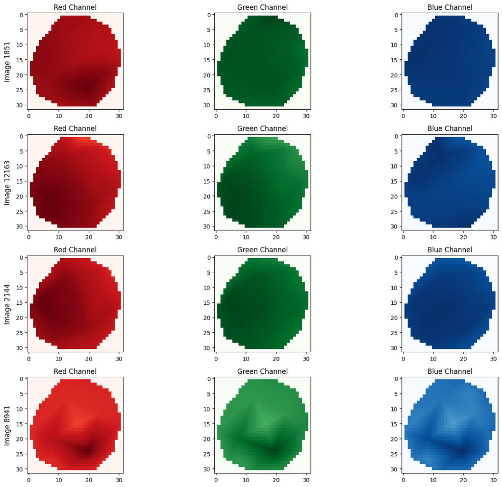

```python
random.seed(28)

image_indices = random.sample(list(metadata_train.index), 4)

# Define the number of images and channels
num_images = len(image_indices)
num_channels = 3

fig, axes = plt.subplots(num_images, num_channels, figsize = (15, 3*num_images))

# Loop through each image
for i, idx in enumerate(image_indices):
    image = final_eeg_images[idx]

    axes[i, 0].text(-0.2, 0.5, f'Image {idx + 1}', transform = axes[i, 0].transAxes,
                    fontsize = 12, rotation = 90, va = 'center', ha = 'center')

    # Loop through each channel
    for j in range(num_channels):

        # Plot the channel
        axes[i, j].imshow(image[3][:, :, j], cmap = 'Reds' if j == 0 else 'Greens' if j == 1 else 'Blues')
        axes[i, j].set_title(['Red Channel', 'Green Channel', 'Blue Channel'][j])

plt.tight_layout()
plt.show()
```

We can also plot images belonging to different activity classes, selected at random, in their RGB condensed form.

```python
random.seed(12)

activity_classes = ['Seizure', 'LPD', 'GPD', 'LRDA', 'GRDA', 'Other']
selected_images = []

for activity_class in activity_classes:

    # Filter the metadata for given class
    rows = metadata_train[metadata_train['expert_consensus'] == activity_class]
    random_indices = random.sample(list(rows.index), 2)

    # Append selected images
    selected_images.append(final_eeg_images[random_indices[0]])
    selected_images.append(final_eeg_images[random_indices[1]])
```

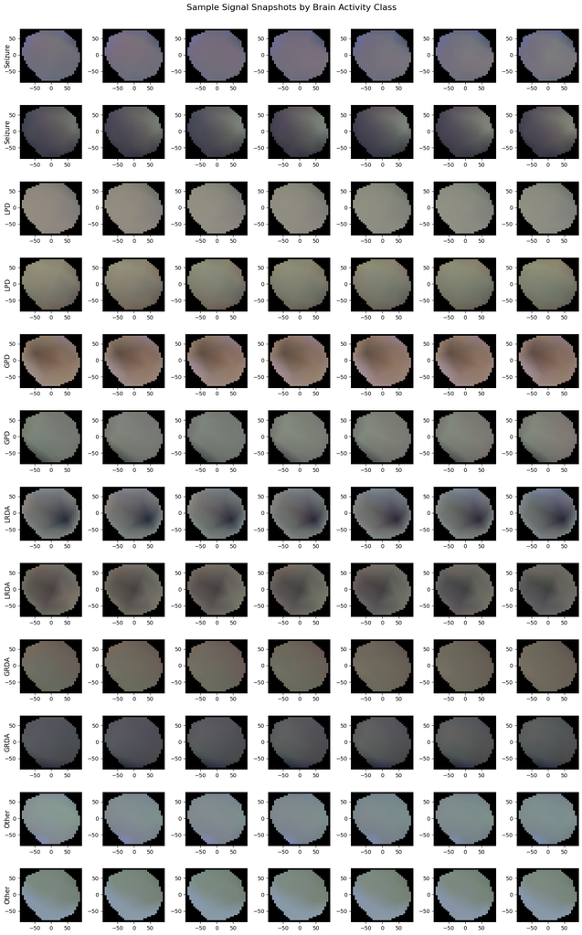

```python
# Define the number of rows and columns for subplots
num_rows = 12
num_cols = 7

# Create a figure and axis object
fig, axs = plt.subplots(num_rows, num_cols, figsize = (15, 2*num_rows))

# Iterate over each set of images
for i, images in enumerate(selected_images):

    # Add row title for every two rows
    activity_index = i // 2
    axs[i, 0].text(-0.2, 0.5, activity_classes[activity_index], transform = axs[i, 0].transAxes,
                   fontsize = 12, rotation = 90, va = 'center', ha = 'center')

    # Plot each image in the current set
    for j, img in enumerate(images):
        axs[i, j].imshow(img, extent = (reduced_df['d1'].min(), reduced_df['d1'].max(),
                                        reduced_df['d2'].min(), reduced_df['d2'].max()), origin = 'lower')

plt.suptitle('Sample Signal Snapshots by Brain Activity Class', fontsize = 16, y = 1)
plt.tight_layout()
plt.show()
```